# Reproducible Research: Peer Assessment 1

## Loading and preprocessing the data

```r
data <- read.csv("activity.csv")
summary(data)
```

```
##      steps               date          interval
##  Min.   :  0.0   2012-10-01:  288   Min.   :   0
##  1st Qu.:  0.0   2012-10-02:  288   1st Qu.: 589
##  Median :  0.0   2012-10-03:  288   Median :1178
##  Mean   : 37.4   2012-10-04:  288   Mean   :1178
##  3rd Qu.: 12.0   2012-10-05:  288   3rd Qu.:1766
##  Max.   :806.0   2012-10-06:  288   Max.   :2355
##  NA's   :2304    (Other)   :15840
```

Transform the date variable into Date format

```r
data$Date<-as.Date(data$date)
```

## What is mean total number of steps taken per day?

Calculate the total number of steps taken each day

```r
steps.per.day<-tapply(data$steps, data$Date, FUN=sum)
```

Histogram of the total number of steps taken each day

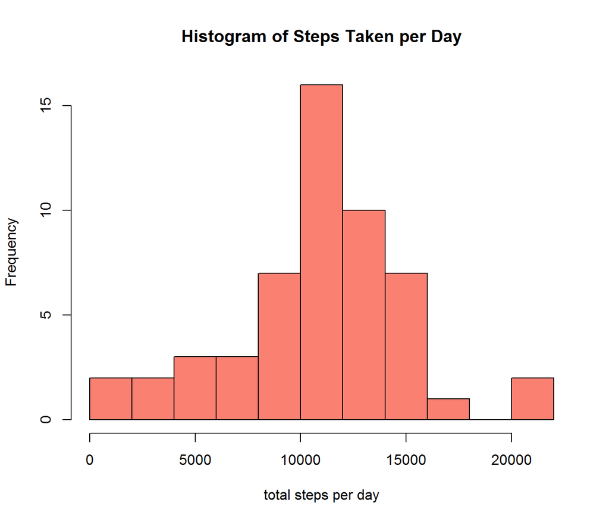

```r
hist(steps.per.day, breaks =15, main = "Histogram of Steps Taken per Day", xlab="total steps per day", col="salmon")
```

Calculate and report the mean and median total number of steps taken per day

```r
steps.mean<-mean(steps.per.day, na.rm=TRUE)
steps.median<-median(steps.per.day, na.rm=TRUE)
```

The mean total number of steps taken per day is 10766.19  
The median total number of steps taken per day is 10765

## What is the average daily activity pattern?

[figure not shown]

```r
plot(y=data$steps, x=data$Date, type="l", col="blue", main="Average number of steps taken by day", ylab="number of steps")
```

## Imputing missing values

Calculate and report the total number of missing values in the dataset

```r
NAs<-sum(is.na(data$steps))
```

The total number of missing values in the dataset is 2304.

I use the mean value of steps taken every five minutes to fill in the missing values. Create a new dataset that is equal to the original dataset but with the missing data filled in.

```r
data2=data
row_NAs <- which(is.na(data2$steps))
data2$steps<-replace(data2$steps, row_NAs, mean(data$steps, na.rm=TRUE))
```

```r
steps.per.day2<-tapply(data2$steps, data$Date, FUN=sum)
```

Histogram of the total number of steps taken each day

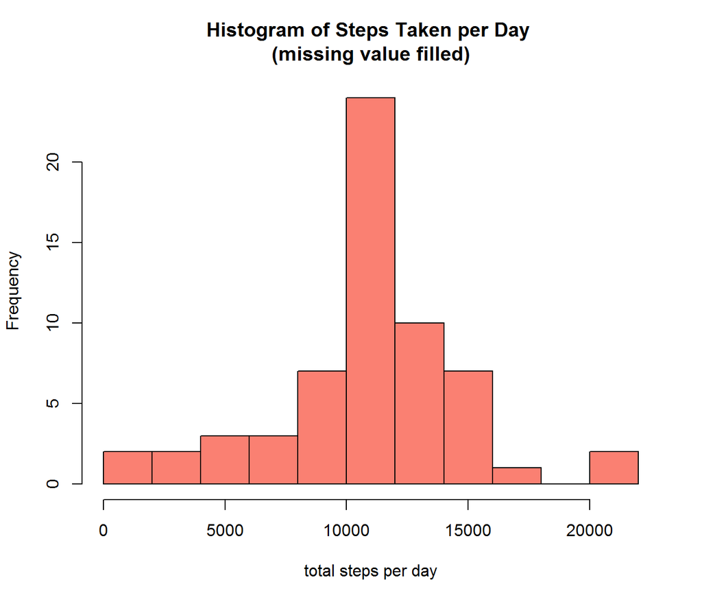

```r
hist(steps.per.day2, breaks=15, main = "Histogram of Steps Taken per Day \n(missing value filled)", xlab="total steps per day", col="salmon")
```

The two graphs are different. The second graph where the missing values are filled have higher frequencies around the mean 10766.19

## Are there differences in activity patterns between weekdays and weekends?

Create a new factor variable in the dataset with two levels – “weekday” and “weekend” indicating whether a given date is a weekday or weekend day.

```r
data2$weekdays<-weekdays(data2$Date)
data2$weekdays2<-ifelse(data2$weekdays %in% c("Saturday", "Sunday"), "weekend", "weekday")
```

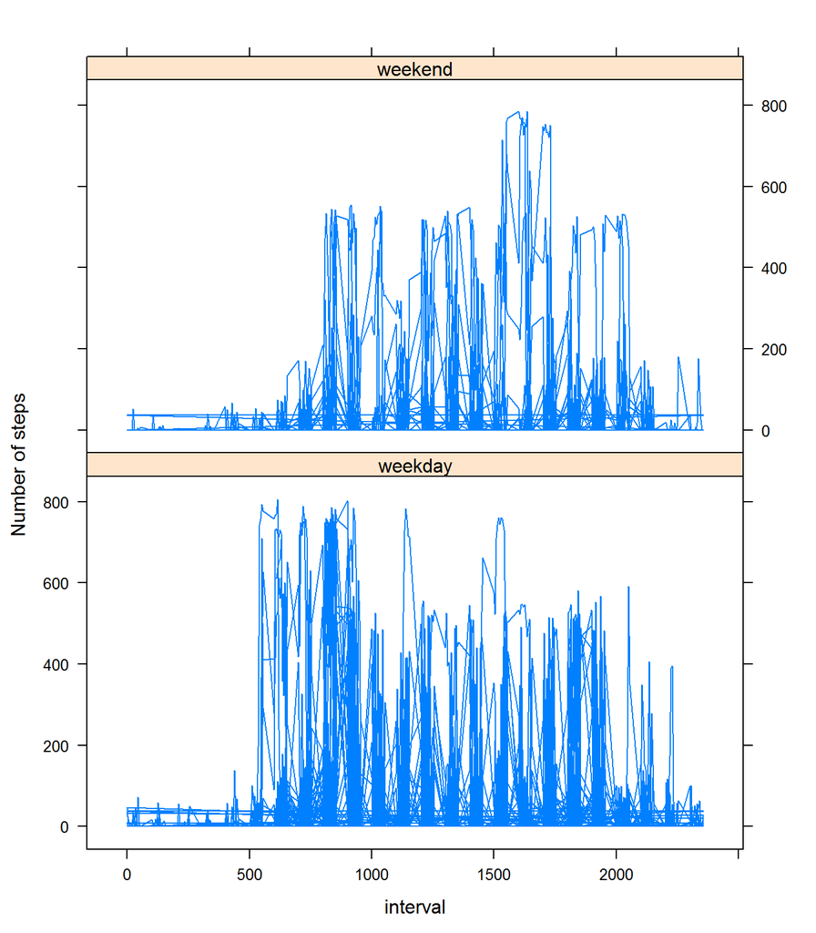

```r
library(lattice)
xyplot(steps ~ interval | weekdays2, data = data2, type = "l", ylab="Number of steps")
```

Yes there are differences in actvity patterns between weekdays and weekends.